# Machine Learning: AllLife Bank Personal Loan Campaign

#### Visualizing the Decision Tree

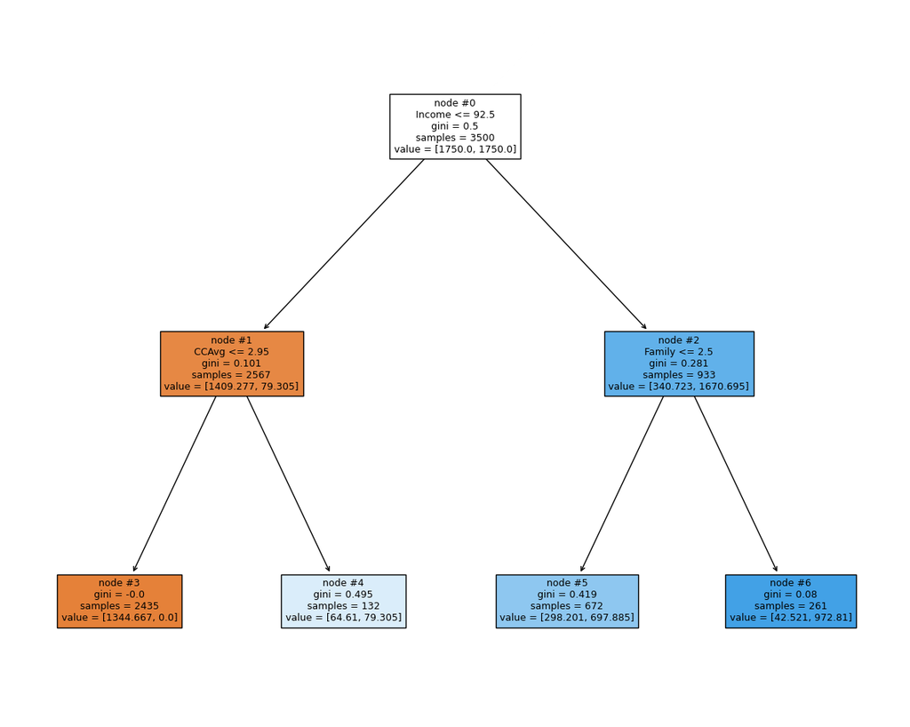

```python
plt.figure(figsize=(15, 12))

tree.plot_tree(
    estimator,
    feature_names=feature_names,
    filled=True,
    fontsize=9,
    node_ids=True,
    class_names=None,
)
plt.show()
```

```python
# Text report showing the rules of a decision tree
print(tree.export_text(estimator, feature_names=feature_names, show_weights=True))
```

```
|--- Income <= 92.50
|   |--- CCAvg <= 2.95
|   |   |--- weights: [1344.67, 0.00] class: 0
|   |--- CCAvg >  2.95
|   |   |--- weights: [64.61, 79.31] class: 1
|--- Income >  92.50
|   |--- Family <= 2.50
|   |   |--- weights: [298.20, 697.89] class: 1
|   |--- Family >  2.50
|   |   |--- weights: [42.52, 972.81] class: 1
```

The decision tree is much simpler with less depth than original - indicating it is more generalized and not over-fitted to the training dataset.

```python
# importance of features in the tree building ( The importance of a feature is computed as the
# (normalized) total reduction of the 'criterion' brought by that feature. It is also known as the Gini importance )
print(
    pd.DataFrame(
        estimator.feature_importances_, columns=["Imp"], index=X_train.columns
    ).sort_values(by="Imp", ascending=False)
)
```

```
                  Imp
Income        0.87653
CCAvg         0.06694
Family        0.05653
Age           0.00000
ZIPCode_94306 0.00000
...               ...
ZIPCode_92104 0.00000
ZIPCode_92103 0.00000
ZIPCode_92101 0.00000
ZIPCode_92096 0.00000
CreditCard_1  0.00000

[478 rows x 1 columns]
```

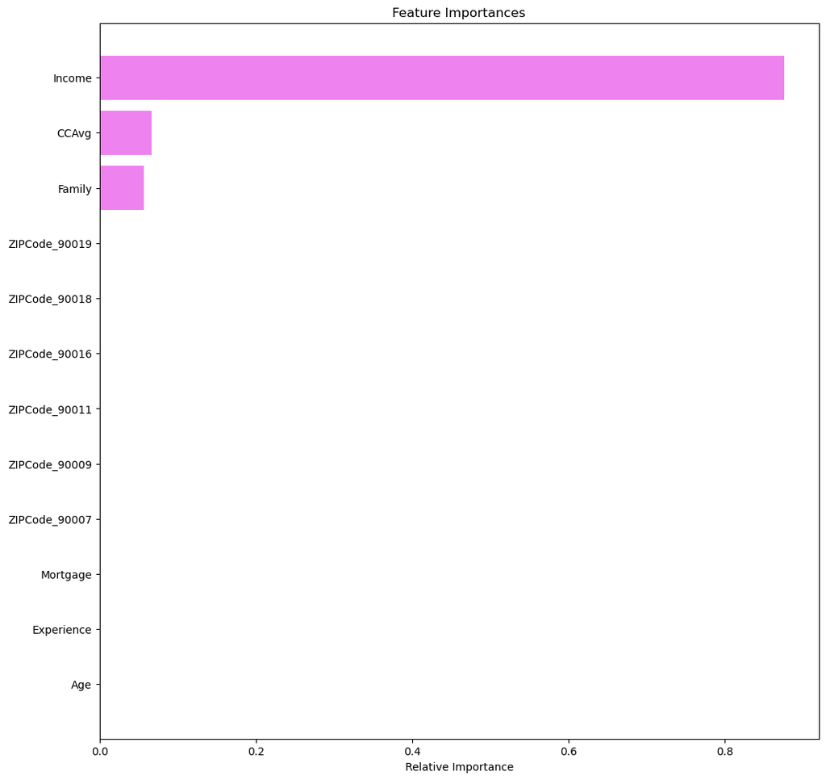

```python
importances = estimator.feature_importances_
'''Remove values that start with "ZIPCode_" from importances'''
importances = importances[~np.array([i.startswith("ZIPCode_") for i in feature_names])]
indices = np.argsort(importances)

plt.figure(figsize=(12, 12))
plt.title("Feature Importances")
plt.barh(range(len(indices)), importances[indices], color="violet", align="center")
plt.yticks(range(len(indices)), [feature_names[i] for i in indices])
plt.xlabel("Relative Importance")
plt.show()
```

Income, Credit Card average balance, and Family size are the most important attributes.

### Decision Tree Model Building (Cost Complexity Post-pruning)

```python
clf = DecisionTreeClassifier(random_state=1, class_weight='balanced')
path = clf.cost_complexity_pruning_path(X_train, y_train)
ccp_alphas, impurities = path.ccp_alphas, path.impurities
```

```python
pd.DataFrame(path)
#As the alpha value increases, the number of nodes decreases, thus the complexity of the tree decreases; however impurity increases leading to less accuracy in training data
```

|  | ccp_alphas | impurities |
| --- | --- | --- |
| 0 | 0.00000 | -0.00000 |
| 1 | 0.00000 | -0.00000 |
| 2 | 0.00000 | -0.00000 |
| 3 | 0.00000 | -0.00000 |
| 4 | 0.00000 | -0.00000 |
| 5 | 0.00029 | 0.00086 |
| 6 | 0.00029 | 0.00317 |
| 7 | 0.00029 | 0.00519 |
| 8 | 0.00030 | 0.00580 |
| 9 | 0.00030 | 0.00763 |
| 10 | 0.00031 | 0.00794 |
| 11 | 0.00032 | 0.00952 |
| 12 | 0.00057 | 0.01009 |
| 13 | 0.00059 | 0.01068 |
| 14 | 0.00059 | 0.01245 |
| 15 | 0.00066 | 0.01378 |
| 16 | 0.00075 | 0.01453 |
| 17 | 0.00077 | 0.01607 |
| 18 | 0.00090 | 0.01697 |
| 19 | 0.00093 | 0.01790 |
| 20 | 0.00151 | 0.01941 |
| 21 | 0.00167 | 0.02108 |
| 22 | 0.00199 | 0.02307 |
| 23 | 0.00222 | 0.02751 |
| 24 | 0.00238 | 0.02989 |
| 25 | 0.00247 | 0.03484 |
| 26 | 0.00330 | 0.03813 |
| 27 | 0.00334 | 0.04148 |
| 28 | 0.00350 | 0.04498 |
| 29 | 0.00360 | 0.05219 |
| 30 | 0.00373 | 0.05592 |
| 31 | 0.00494 | 0.06086 |
| 32 | 0.00497 | 0.07080 |
| 33 | 0.02256 | 0.09336 |
| 34 | 0.03709 | 0.20462 |
| 35 | 0.29538 | 0.50000 |

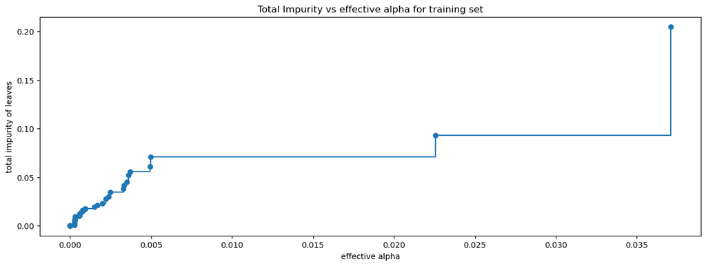

```python
fig, ax = plt.subplots(figsize=(15, 5))
ax.plot(ccp_alphas[:-1], impurities[:-1], marker="o", drawstyle="steps-post")
ax.set_xlabel("effective alpha")
ax.set_ylabel("total impurity of leaves")
ax.set_title("Total Impurity vs effective alpha for training set")
plt.show()
```

Next, we train a decision tree using the effective alphas. The last value in `ccp_alphas` is the alpha value that prunes the whole tree, leaving the tree, `clfs[-1]`, with one node.

```python
clfs = []
for ccp_alpha in ccp_alphas:
    clf = DecisionTreeClassifier(random_state=1, ccp_alpha=ccp_alpha, class_weight='balanced')
    clf.fit(X_train, y_train)
    clfs.append(clf)
print(
    "Number of nodes in the last tree is: {} with ccp_alpha: {}".format(
        clfs[-1].tree_.node_count, ccp_alphas[-1]
    )
)
```

```
Number of nodes in the last tree is: 1 with ccp_alpha: 0.29537927599923225
```

For the remainder, we remove the last element in `clfs` and `ccp_alphas`, because it is the trivial tree with only one node. Here we show that the number of nodes and tree depth decreases as alpha increases.

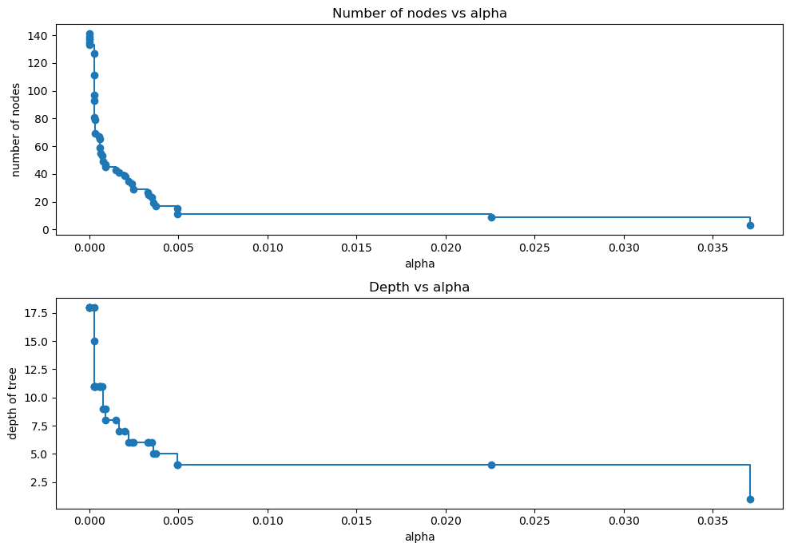

```python
clfs = clfs[:-1]
ccp_alphas = ccp_alphas[:-1]

node_counts = [clf.tree_.node_count for clf in clfs]
depth = [clf.tree_.max_depth for clf in clfs]
fig, ax = plt.subplots(2, 1, figsize=(10, 7))
ax[0].plot(ccp_alphas, node_counts, marker="o", drawstyle="steps-post")
ax[0].set_xlabel("alpha")
ax[0].set_ylabel("number of nodes")
ax[0].set_title("Number of nodes vs alpha")
ax[1].plot(ccp_alphas, depth, marker="o", drawstyle="steps-post")
ax[1].set_xlabel("alpha")
ax[1].set_ylabel("depth of tree")
ax[1].set_title("Depth vs alpha")
fig.tight_layout()
```